# MBA561 K002 - Team Final Project

Shawn Abdian, Lexie Brown, Sharon Buller, Neelavathi Jeyakumar, Bryan Yang

May 10, 2022

## Task 1.

**Load the libraries that you will use in this project.**

```r
library(dplyr)
library(magrittr)
library(lubridate)
library(stringr)
library(tidyr)
```

## Task 2.

**Read in the data from the ities.csv and max_temp.csv files as dataframe objects df and df_weather_weekly respectively.**

```r
df <- read.csv("ities.csv", stringsAsFactors = T)
df_weather_weekly <- read.csv("max_temp.csv")
```

## Task 3.

**(1 point) Use an appropriate R function to display the number of rows and columns in the df and df_weather dataframes.**

```r
dim(df)
```

```
## [1] 438151     13
```

```r
dim(df_weather_weekly)
```

```
## [1] 52  9
```

**Answer**: **df** has 438,151 rows and 13 columns and **df_weather_weekly** has 52 rows and 9 columns.

## Task 4.

**(4 points) Using any functions you want, make any necessary datatype conversions to columns in df and/or df_weather_weekly. Display the structures of the dataframes, df and df_weather_weekly to verify that the datatype conversions, if any, worked. Below the output, comment on why you did or did not make datatype conversions.**

(Hint: You may want to come back to this task and update it once you start working on the subsequent tasks.)

```r
#Step 1 - Delete Week column
df_weather_weekly$Week <- NULL

#Step 2 - Relocate the WeekStarting as the first column
df_weather_weekly <- df_weather_weekly %>% relocate(WeekStarting, .before = Monday)

#Step 3 - Convert date column as a Date data type for both df and df_weather_weekly dataframe
df$Date <- mdy(df$Date)
df_weather_weekly$WeekStarting <- mdy(df_weather_weekly$WeekStarting)

#Step 4 - Re-arrange the df dataframe in an ascending date order similar to df_weather_weekly dataframe
df <- df %>% arrange(Date)

#Step 5 - Filter out the RETURNs and only keep the SALEs line items
summary(df$OperationType)
```

```
## RETURN   SALE
##    349 437802
```

```r
df <- df %>% filter(OperationType %in% c('SALE'))

#Display the structures of the dataframes, df and df_weather_weekly to verify that the datatype conversions
str(df)
```

```
## 'data.frame':    437802 obs. of  13 variables:
##  $ Date             : Date, format: "2014-01-04" "2014-01-04" ...
##  $ OperationType    : Factor w/ 2 levels "RETURN","SALE": 2 2 2 2 2 2 2 2 2 2 ...
##  $ CashierName      : Factor w/ 56 levels "Aimee Port","Alberta Lynch",..: 54 54 54 54 54 54 54 54 54 54 ...
##  $ LineItem         : Factor w/ 68 levels "Aubergine and Chickpea Vindaloo",..: 37 51 37 68 38 68 68 68 9 14 ...
##  $ Department       : Factor w/ 9 levels "Beverage","Catering",..: 1 8 1 8 5 8 8 8 4 6 ...
##  $ Category         : Factor w/ 21 levels "Aubergine and Chickpea Vindaloo",..: 10 18 10 21 16 21 21 21 11 2 ...
##  $ RegisterName     : Factor w/ 12 levels "FT136","FT137",..: 3 3 3 3 3 3 3 3 3 3 ...
##  $ StoreNumber      : Factor w/ 70 levels "AZ23501251","AZ23501258",..: 4 15 4 21 30 21 21 21 23 11 ...
##  $ TransactionNumber: Factor w/ 161058 levels "00002G3137186",..: 151195 151195 119434 119434 143438 99395 141618 141618 52407 159987 ...
##  $ CustomerCode     : Factor w/ 9110 levels "C0010348848",..: 8245 8245 8245 8245 8245 8245 8245 8245 8245 8245 ...
##  $ Price            : num  2.88 2.88 2.88 4.5 37.43 ...
##  $ Quantity         : int  1 1 1 1 1 1 1 1 1 1 ...
##  $ TotalDue         : num  2.88 2.88 2.88 4.5 37.43 ...
```

```r
str(df_weather_weekly)
```

```
## 'data.frame':    52 obs. of  8 variables:
##  $ WeekStarting: Date, format: "2016-01-03" "2016-01-10" ...
##  $ Monday      : num  46.9 48.9 48 34 51.1 ...
##  $ Tuesday     : num  45 46 52 41 60.1 ...
##  $ Wednesday   : num  41 46 53.1 51.1 57.9 ...
##  $ Thursday    : num  45 46.9 55 46.9 51.1 ...
##  $ Friday      : num  59 51.1 50 55.9 41 ...
##  $ Saturday    : num  57 42.1 51.1 51.1 48 ...
##  $ Sunday      : num  57 48.9 50 36 52 ...
```

**Answer:** We did not change ‘Department’, ‘LineItem’, and ‘Category’ since they will not be used in the calculations or any of the comparisons. We have decided to perform the following steps so it will help us to find a relationship (if any) in “Daily Sales” amoung the quantiy purchased, the price paid, and the maxium temperature:

Step 1: Deletes “Week” column from ‘df_weather_weekly’ since we do not need the number of week counters in this project, therefore, to simplify the dataframe, the “Week” column is deleted.

Step 2: Relocates the “WeekStarting” as the first column in ‘df_weather_weekly’.

Step 3: By converting the Date columns as the ‘date type’, we can easily compare and calculate according for ‘df’ and ‘df_weather_week’ dataframe in succeeding tasks.

Step 4: Currently, the ‘df’ dataframe is sorted in a descending date order. We need to re-arrange the ‘df’ in ascending date order similar to the ‘df_weather_weekly’ dataframe.

Step 5: There are two operation types, RETRUN and SALE. There are 349 returns and 437,802 sales. We want to filter out the RETURNs and only keep the SALEs, since we want to find out if there is a relationship in “daily sales” among the quantity purchased, the price paid, and the maximum temperature.

## Task 5.

**(1 point) Display summaries of the columns in the dataframes, df and df_weather_weekly.**

```r
summary(df)
```

```
##       Date            OperationType            CashierName
##  Min.   :2014-01-04   RETURN:     0   Wallace Kuiper : 79191
##  1st Qu.:2014-09-11   SALE  :437802   Irving Burgos  : 25009
##  Median :2015-06-26                   Diana Miller   : 24860
##  Mean   :2015-07-11                   Rachael Price  : 24333
##  3rd Qu.:2016-04-26                   Vincent Ball   : 23532
##  Max.   :2017-04-05                   Stephanie Raven: 20703
##                                       (Other)        :240174
##                         LineItem         Department
##  Salmon and Wheat Bran Salad: 88981   Entrees :152474
##  Chicken and Onion Kabob    : 51325   Kabobs  :101975
##  Beef and Squash Kabob      : 34729   Sides   : 97220
##  Yogurt                     : 33185   Beverage: 35723
##  Beef and Apple Burgers     : 32230   general : 27845
##  Fountain Drink             : 29371   Salad   : 20848
##  (Other)                    :167981   (Other) :  1717
##                         Category       RegisterName        StoreNumber
##  Salmon and Wheat Bran Salad: 72551   RT149  :160699   AZ23501305: 72551
##  Chicken                    : 51325   RT147  :109212   AZ23501336: 51325
##  general                    : 49447   RT145  : 67602   AZ23501367: 34729
##  Beef                       : 34729   RT135  : 24940   AZ23501596: 33185
##  Yogurt                     : 33185   RT146  : 21119   AZ23501258: 32230
##  Beef and Apple Burgers     : 32230   RT151  : 20069   AZ23501289: 29371
##  (Other)                    :164335   (Other): 34161   (Other)   :184411
##      TransactionNumber       CustomerCode        Price
##  00XHLAF147696:    64   CWM11331L8O:393342   Min.   :   -0.34
##  00QG7IM183127:    45   CNJ6039IN9 :   162   1st Qu.:    4.50
##  00HIKMB68419 :    42   CJ04273UTK :    82   Median :   11.29
##  00N79DD84626 :    40   C9E3494ICE :    75   Mean   :   14.45
##  00SMJ8R148203:    39   C5D11136WBI:    72   3rd Qu.:   14.68
##  009DZG9134033:    37   CZW6572NTE :    68   Max.   :21449.97
##  (Other)      :437535   (Other)    : 44001   NA's   :12
##     Quantity          TotalDue
##  Min.   :  1.000   Min.   :  -32.60
##  1st Qu.:  1.000   1st Qu.:    4.50
##  Median :  1.000   Median :   11.88
##  Mean   :  1.177   Mean   :   15.35
##  3rd Qu.:  1.000   3rd Qu.:   15.04
##  Max.   :815.000   Max.   :21449.97
##                    NA's   :12
```

```r
summary(df_weather_weekly)
```

```
##   WeekStarting            Monday          Tuesday         Wednesday
##  Min.   :2016-01-03   Min.   : 33.98   Min.   : 28.94   Min.   : 30.92
##  1st Qu.:2016-04-01   1st Qu.: 48.92   1st Qu.: 50.00   1st Qu.: 51.98
##  Median :2016-06-29   Median : 67.46   Median : 68.00   Median : 65.93
##  Mean   :2016-06-29   Mean   : 68.29   Mean   : 68.12   Mean   : 69.19
##  3rd Qu.:2016-09-26   3rd Qu.: 88.30   3rd Qu.: 87.58   3rd Qu.: 89.28
##  Max.   :2016-12-25   Max.   :100.94   Max.   :100.94   Max.   :102.02
##     Thursday          Friday          Saturday          Sunday
##  Min.   : 30.92   Min.   : 33.08   Min.   : 28.94   Min.   : 33.98
##  1st Qu.: 50.54   1st Qu.: 55.45   1st Qu.: 53.96   1st Qu.: 51.98
##  Median : 67.01   Median : 65.03   Median : 68.54   Median : 70.52
##  Mean   : 69.41   Mean   : 70.68   Mean   : 70.58   Mean   : 69.25
##  3rd Qu.: 89.56   3rd Qu.: 91.27   3rd Qu.: 89.56   3rd Qu.: 89.96
##  Max.   :100.94   Max.   :104.00   Max.   :102.02   Max.   :102.92
```

## Task 6.

**(3 points) Display the count of missing values in each column of df. Choose to remove or impute the missing values and defend that choice in 1-2 sentences for each column with missing values.**

```r
colSums(is.na(df))                   # display # of rows with missing values in each column of df
```

```
##              Date     OperationType       CashierName          LineItem
##                 0                 0                 0                 0
##        Department          Category      RegisterName       StoreNumber
##                 0                 0                 0                 0
## TransactionNumber      CustomerCode             Price          Quantity
##                 0                 0                12                 0
##          TotalDue
##                12
```

```r
df %<>% filter(!is.na(Price))
```

**Answer:** There are 437,802 SALE line items in the df dataset. Of the 437,802 SALE line items, only 12 of the line items have NA in the Price and the TotalDue, which is a very small percentage and most likely due to an error. By removing these 12 lines, it will NOT diminish or heighten the effect of the outliers. Therefore, we can remove these line items instead of imputing the missing values.

## Task 7.

**(4 points) Let’s now explore whether there is a relationship in daily sales among the quantity purchased, the price paid, and the maximum temperature. To do so, we will want to aggregate the data at the daily level. Thus, please start by creating a new dataset df_daily by aggregating the dataframe df at the daily level. The dataframe df_daily must have the columns Quantity and TotalDue from df summarized at the daily level. Display a summary of df_daily. In one to two sentences defend the choice of summary measure (sum, mean, or other) used to aggregate the values in each column.**

```r
#Making df_daily from df by aggregating the dataframe at the daily level
df_daily <- df %>%
  mutate(
    date = round_date(Date, 'day')
  ) %>%
  group_by(Date) %>%
  summarise(
    AvgPrice = mean(Price)
    , MedPrice = median(Price, na.rm = T)
    , Quantity = n()
    , TotalDue = sum(TotalDue, na.rm = T)
  ) %>%
  ungroup()
summary(df_daily)
```

```
##       Date               AvgPrice         MedPrice         Quantity
##  Min.   :2014-01-04   Min.   :  0.75   Min.   :  0.75   Min.   :   1.0
##  1st Qu.:2014-10-25   1st Qu.: 11.67   1st Qu.: 10.99   1st Qu.: 335.0
##  Median :2015-08-17   Median : 12.79   Median : 11.29   Median : 407.0
##  Mean   :2015-08-18   Mean   : 15.42   Mean   : 11.73   Mean   : 428.8
##  3rd Qu.:2016-06-11   3rd Qu.: 15.25   3rd Qu.: 12.02   3rd Qu.: 513.0
##  Max.   :2017-04-05   Max.   :390.04   Max.   :123.72   Max.   :1056.0
##     TotalDue
##  Min.   :    9
##  1st Qu.: 4662
##  Median : 5985
##  Mean   : 6583
##  3rd Qu.: 7970
##  Max.   :28114
```

**Answer**: We have decided to summarize the following five variables in df_daily: Date, AvgPrice, MedPrice, Quantity, and TotalDue. Date is the primary key. The Average and the Median prices show the observable patterns of the sale items on a daily basis (i.e in majority of the days, the Median daily price of a line item is 11.29 and the Median total sale amount is 5,985). The Quantity shows the total number of Sale items that are sold each day. The TotalDue shows the Total Sales amount for each day. (i.e. in majority of the days, the Median sales items sold is 407 and the Median total sales amount is 5,985 dollars.

## Task 8.

**(4 points) Create a new dataframe, df_weather_daily, by pivoting the dataframe df_weather_weekly from wide to long such that names of the seven columns (Monday:Sunday) are in a new column day and the values from those seven columns (Monday:Sunday) are in a new column max_temp. Display the first 10 rows of df_weather_daily to verify that the pivot worked.**

```r
# Convert df_weather_weekly to df_weather_daily by pivoting the dataframe from wide to long
df_weather_daily <- df_weather_weekly %>%
  pivot_longer(cols = c(Monday:Sunday)
              , names_to = 'DayoftheWeek'
              , values_to = 'MaxTemp')

# Display the first 10 rows to verify the pivot worked
df_weather_daily[1:10,]
```

```
## # A tibble: 10 × 3
##    WeekStarting DayoftheWeek MaxTemp
##    <date>       <chr>          <dbl>
##  1 2016-01-03   Monday          46.9
##  2 2016-01-03   Tuesday         45.0
##  3 2016-01-03   Wednesday       41
##  4 2016-01-03   Thursday        45.0
##  5 2016-01-03   Friday          59
##  6 2016-01-03   Saturday        57.0
##  7 2016-01-03   Sunday          57.0
##  8 2016-01-10   Monday          48.9
##  9 2016-01-10   Tuesday         46.0
## 10 2016-01-10   Wednesday       46.0
```

## Task 9.

**(4 points) Update the df_weather_daily dataframe by adding a column, Date, that corresponds to the value in the day column. For example, if the WeekStarting value is “2016-01-03”, then the value in the Date column for the Monday that comes after “2016-01-03” should have a value of “2016-01-04”. Arrange df_weather_daily in ascending order of Date and display the first 10 rows to verify that it worked. Beneath the output comment on how you know that the creation of the Date column worked.**

```r
# calculate numeric value that corresponds to the value in the day column
df_weather_daily <- df_weather_daily %>%
  mutate(
   Day_num = case_when(
    DayoftheWeek == 'Sunday' ~ '0'
    , DayoftheWeek == 'Monday' ~ '1'
    , DayoftheWeek == 'Tuesday' ~ '2'
    , DayoftheWeek == 'Wednesday' ~ '3'
    , DayoftheWeek == 'Thursday' ~ '4'
    , DayoftheWeek == 'Friday' ~ '5'
    , DayoftheWeek == 'Saturday' ~ '6'
    )
  , Date = WeekStarting + as.numeric(Day_num)        # calculate Date corresponds to the value in the day column
  ) %>%
  arrange(Date) %>%                                  # arrange df_weather_daily in ascending order of the dates
  relocate(Date, .before = WeekStarting)             # relocate Date in the first column

df_weather_daily$Day_num <- NULL                     # get rid of Day_num col

df_weather_daily[1:10,]                              # show the first 10 rows to verify.
```

```
## # A tibble: 10 × 4
##    Date       WeekStarting DayoftheWeek MaxTemp
##    <date>     <date>       <chr>          <dbl>
##  1 2016-01-03 2016-01-03   Sunday          57.0
##  2 2016-01-04 2016-01-03   Monday          46.9
##  3 2016-01-05 2016-01-03   Tuesday         45.0
##  4 2016-01-06 2016-01-03   Wednesday       41
##  5 2016-01-07 2016-01-03   Thursday        45.0
##  6 2016-01-08 2016-01-03   Friday          59
##  7 2016-01-09 2016-01-03   Saturday        57.0
##  8 2016-01-10 2016-01-10   Sunday          48.9
##  9 2016-01-11 2016-01-10   Monday          48.9
## 10 2016-01-12 2016-01-10   Tuesday         46.0
```

**Answer:** The first 10 rows reflect the corrected date of the week. Jan 3, 2016 is a Sunday. Jan 4, 2016 is a Monday and so forth.

## Task 10.

**(2 points) Join the dataframes df_daily and df_weather_daily into one dataframe df_final such that only the rows that are in both df_daily and df_weather_daily are in df_final. Arrange df_final in ascending order of Date. Then display something to show that the join worked. Briefly identify how that output helps you know that the join worked.**

```r
#Join the dataframes in a way that only the rows that are in both dataframes in acending order of date.
df_final <- df_daily %>% inner_join(df_weather_daily, by = 'Date')

#Disable WeekStarting on the df_final
df_final$WeekStarting <- NULL

#Relocate DayoftheWeek column to the second column.
df_final <- df_final %>% relocate(DayoftheWeek, .after = Date)

#Show first 10 rows from df_final
df_final[1:10,]
```

```
## # A tibble: 10 × 7
##    Date       DayoftheWeek AvgPrice MedPrice Quantity TotalDue MaxTemp
##    <date>     <chr>           <dbl>    <dbl>    <int>    <dbl>   <dbl>
##  1 2016-01-05 Tuesday          11.7     11.9      272    3358.    45.0
##  2 2016-01-06 Wednesday        11.6     12.0      299    3935.    41
##  3 2016-01-07 Thursday         17.3     12.0      332    5966.    45.0
##  4 2016-01-08 Friday           11.5     11.7      516    6193.    59
##  5 2016-01-09 Saturday         11.9     12.2      490    6857.    57.0
##  6 2016-01-11 Monday           12.6     11.0      302    4077.    48.9
##  7 2016-01-12 Tuesday          11.6     11.0      296    3518.    46.0
##  8 2016-01-13 Wednesday        20.7     12.0      288    6576.    46.0
##  9 2016-01-14 Thursday         13.5     11.3      397    5629.    46.9
## 10 2016-01-15 Friday           11.4     11.0      519    6282.    51.1
```

## Task 11.

**(4 points) Display a pairplot like the one demonstrated towards the end of the module 2 video, “Getting to Know Your Data 3: Summary Statistics for Each Column, and Quick Plots”. Create this pairplot for three columns from df_final: Quantity, TotalDue, and max_temp. Below the output, identify whether there appears to be a two-way relationship for each of the two-way combination of variables: Quantity & TotalDue, Quantity & max_temp, and TotalDue & max_temp.**

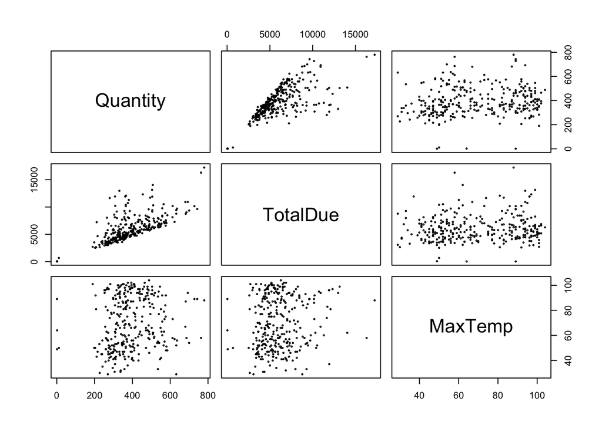

```r
plot(df_final[,c('Quantity', 'TotalDue', 'MaxTemp')], cex = 0.3)
```

```r
summary(df_final$MaxTemp)
```

```
##    Min. 1st Qu.  Median    Mean 3rd Qu.    Max.
##   28.94   51.98   66.92   69.66   89.51  104.00
```